# Missing Data

Dean Adams, Iowa State University

09 April, 2019

# The Problem of Missing Data

- GPA: Aligns specimens to the average shape (reference, consensus shape)
  - Removes non-shape information
  - Requires landmark correspondence among specimens, and that all landmarks must be present on all specimens

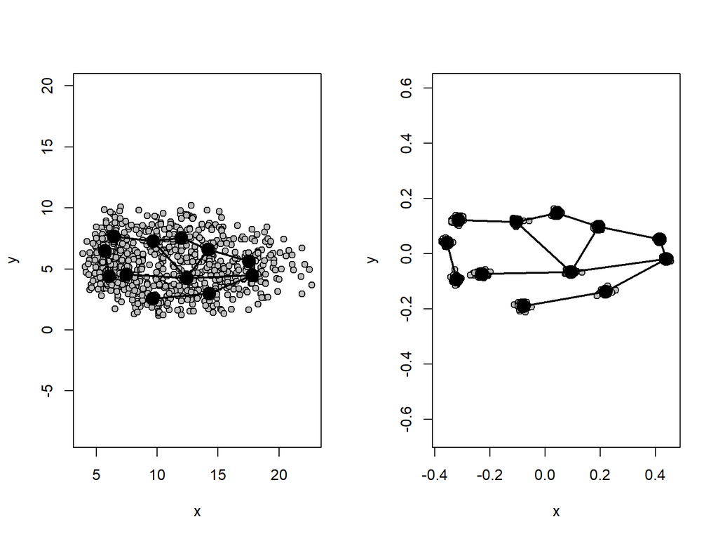

- What does one do when specimens have missing data?

# Missing Data

- In some fields (e.g., anthropology), missing data is pervasive
  - Specimens are incomplete, or lack structures entirely

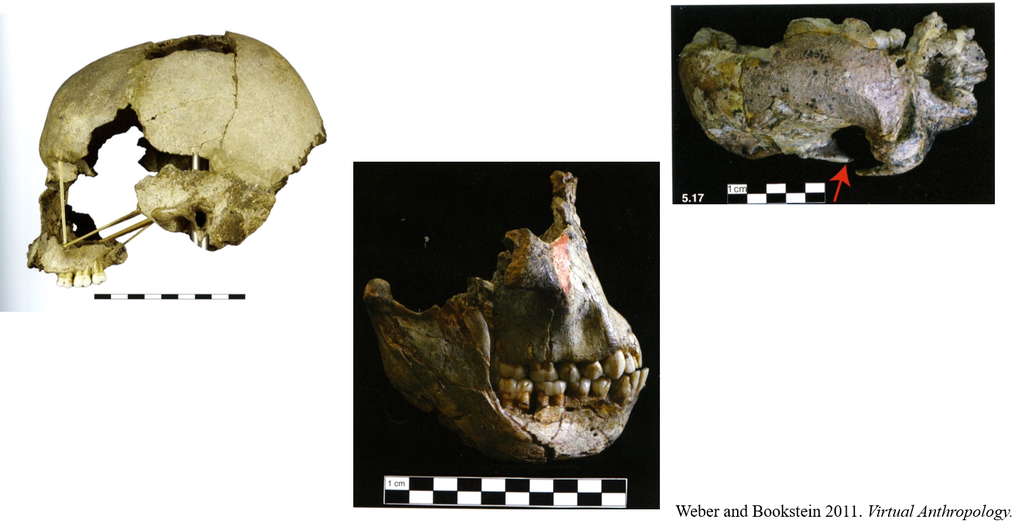

# Dealing with Missing Data: Delete Specimens

- Simplest solution is to remove specimens with missing data

# Dealing with Missing Data: Delete Specimens

- Simplest solution is to remove specimens with missing data

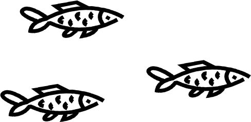

- Reduces sample size
- No information from deleted specimens, which could be important (e.g., a rare species)
- NOT an optimal solution!

# Dealing with Missing Data: Delete Landmarks

- Another option is to delete landmarks that are missing from some specimens

# Dealing with Missing Data: Delete Landmarks

- Another option is to delete landmarks that are missing from some specimens

[figure not shown]

- Retains original sample size
- No information from deleted landmarks, which could be biologically important
- NOT an optimal solution!

# Estimate Missing Data

- An alternative is to estimate missing data in some intelligent manner
- Goal is to generate ‘complete’ specimens by estimating missing landmarks
  - Called data *imputation* in the statistical literature
- Use some reasonable procedure to predict missing landmark locations
- Several approaches possible

###### See Gunz et al. (2009). *J. Hum. Evol.*

# 1: Exploiting Symmetry

- Use biological symmetry to estimate missing landmarks
- Two approaches:
  - 1: Mirror-image (reflect) portion of structure to the other side
  - 2: Create $\small{2}^{nd}$ full specimen via reflection (and relabeled)
- Locations of missing landmarks estimated from location in reflected portion

# 1: Exploiting Symmetry

- Use biological symmetry to estimate missing landmarks
- Two approaches:
  - 1: Mirror-image (reflect) portion of structure to the other side
  - 2: Create $\small{2}^{nd}$ full specimen via reflection (and relabeled)
- Locations of missing landmarks estimated from location in reflected portion

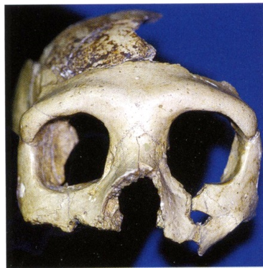

# 1: Exploiting Symmetry

- Use biological symmetry to estimate missing landmarks
- Two approaches:
  - 1: Mirror-image (reflect) portion of structure to the other side
  - 2: Create $\small{2}^{nd}$ full specimen via reflection (and relabeled)
- Locations of missing landmarks estimated from location in reflected portion

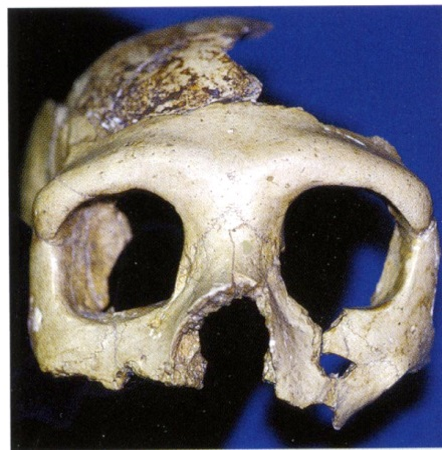

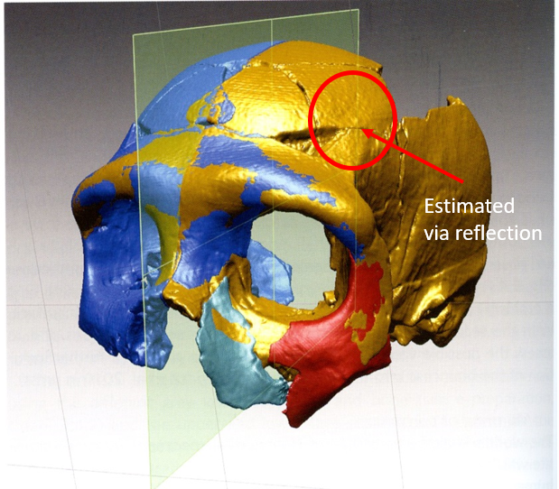

# Exploiting Symmetry: Example

- Here we have the lizard head dataset
- Let’s take one specimen (in red) and eliminate some landmarks

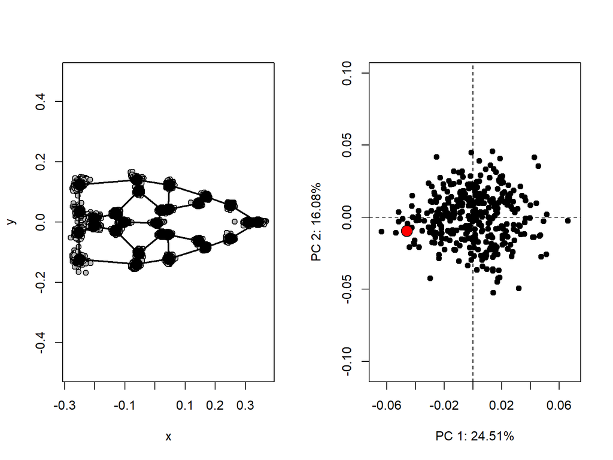

# Exploiting Symmetry: Example

- Here we have the lizard head dataset
- Let’s take one specimen (in red) and eliminate some landmarks

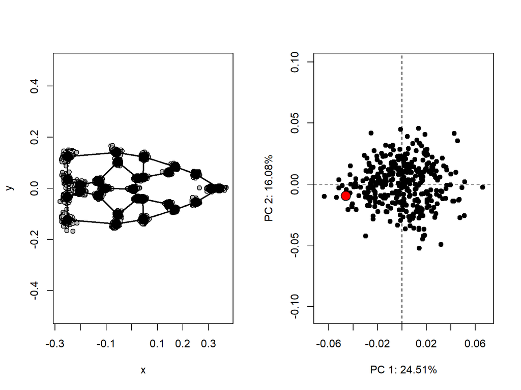

- Let’s delete some landmarks then estimate by exploiting symmetry

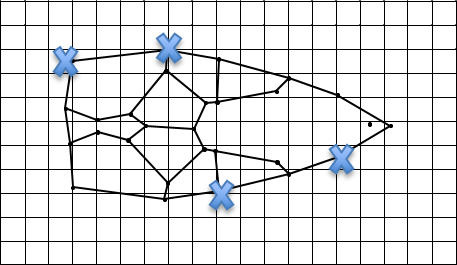

# Exploiting Symmetry: Test Procedure

- 1: Obtain specimen, delete landmarks
- 2: Estimate landmarks via symmetry
- 3: Calculate $\small{D}_{Proc}$ between original and estimated

# Exploiting Symmetry: Test Procedure

- 1: Obtain specimen, delete landmarks
- 2: Estimate landmarks via symmetry
- 3: Calculate $\small{D}_{Proc}$ between original and estimated

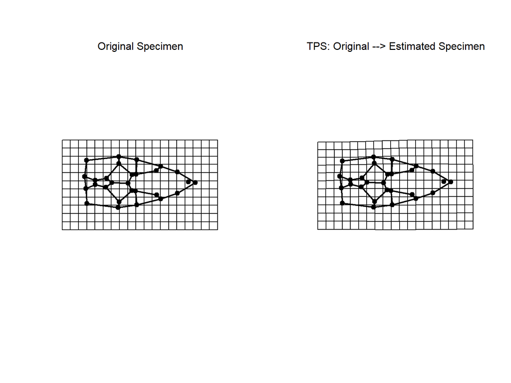

$\small{D}_{Proc}= 0.009$. Pretty good!

# Exploiting Symmetry

- **Advantages**
  - Exploits spatial relationships of anatomy within a specimen
  - Leverages ‘pseudoreplication’ of symmetric points
- **Disadvantages**
  - Not all objects are symmetric
  - Studies of asymmetry are challenged, because by definition only the symmetric portion of shape is used in the reconstruction
- Symmetry methods can be useful but not are not a general solution (limited to symmetric structures)

# 2: Mean Substitution

- Use landmarks in reference to estimate missing landmarks
  - 1: Superimpose all complete specimens
  - 2: Obtain reference (average)
  - 3: Replace missing landmarks with values from reference

###### see Arbour and Brown. (2014). *Methods. Ecol. Evol.*

# Mean Substitution: Example

- Here we have some (simulated) fish data:

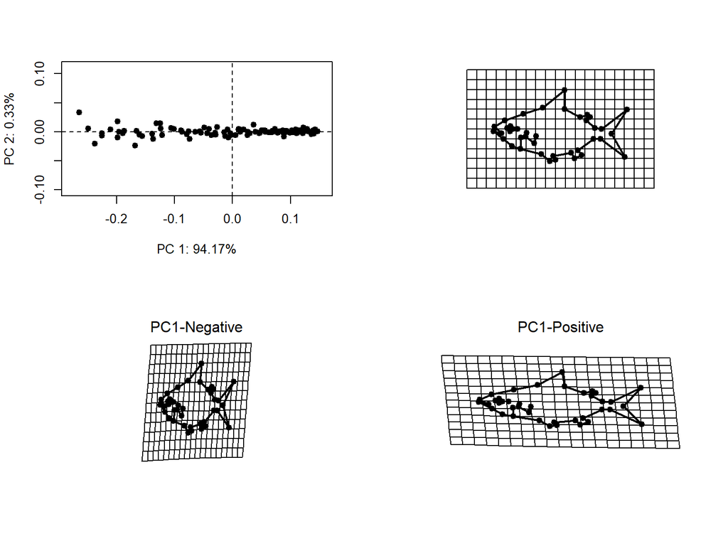

- Let’s create missing landmarks for several specimens and predict via mean substitution

# Mean Substitution: Example 1

- Let’s take one specimen (in red) and eliminate some landmarks

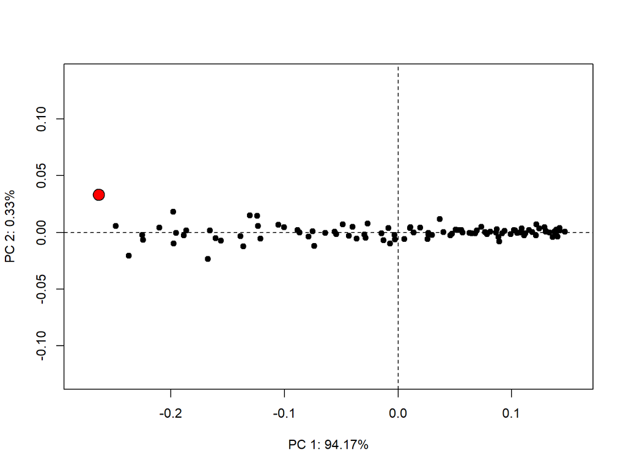

- Now let’s delete some landmarks then estimate by mean substitution

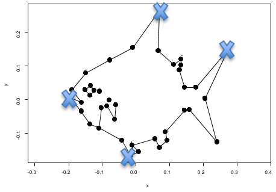

# Mean Substitution: Example 1 (Cont.)

Test Procedure

- 1: Obtain specimen, delete landmarks
- 2: Estimate landmarks from mean specimen
- 3: Calculate $\small{D}_{Proc}$ between original and estimated

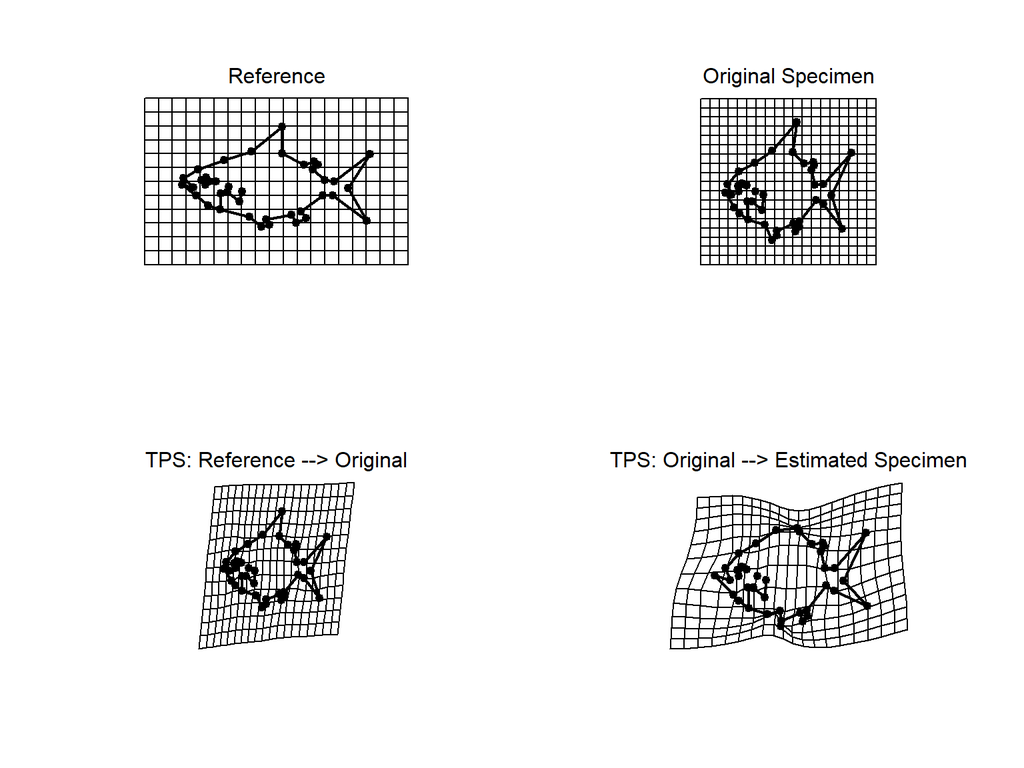

$\small{D}_{Proc_{Ref-Orig}} = 0.26$ $\small{D}_{Proc_{Ref-Est}} = 0.23$

$\small{D}_{Proc_{Orig-Est}} = 0.13$ **Not good at all!**

# Mean Substitution: Example 2

- Or let’s take a different specimen (in red) and eliminate some landmarks

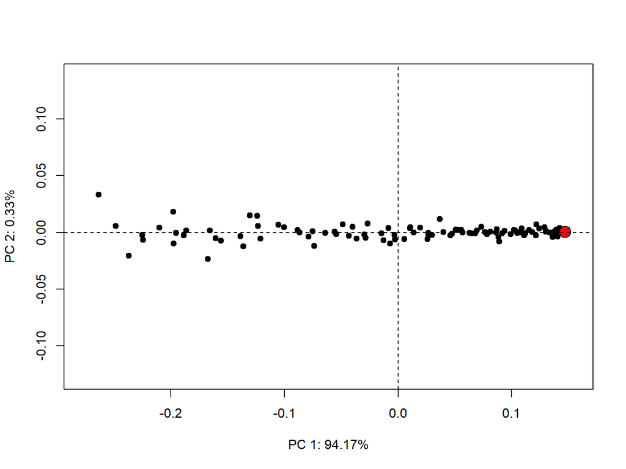

- Now let’s delete some landmarks then estimate by mean substitution

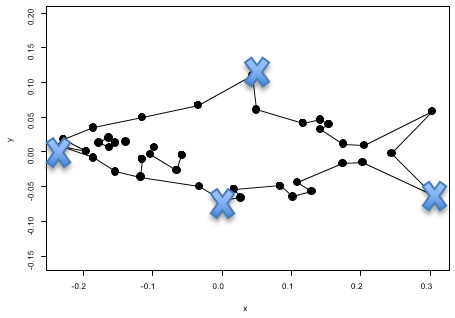

# Mean Substitution: Example 2 (Cont.)

Test Procedure

- 1: Obtain specimen, delete landmarks
- 2: Estimate landmarks from mean specimen
- 3: Calculate $\small{D}_{Proc}$ between original and estimated

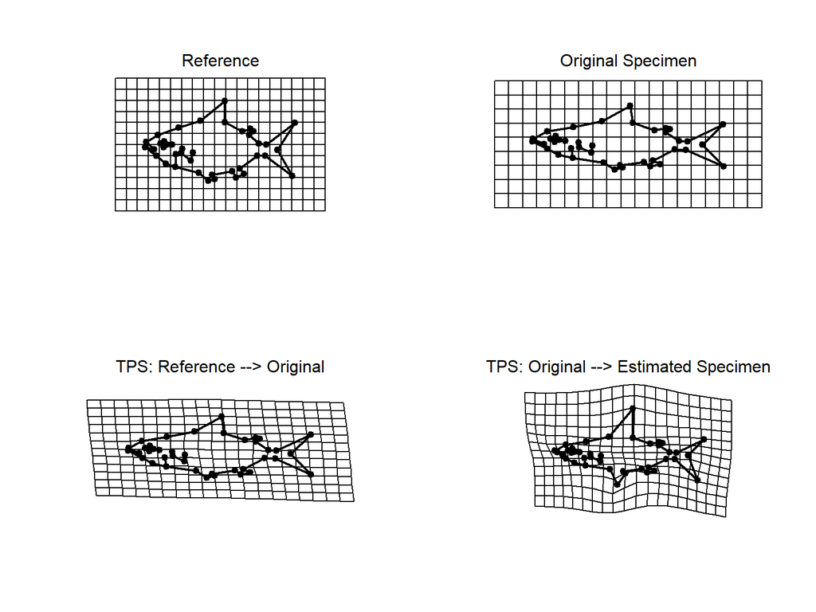

$\small{D}_{Proc_{Ref-Orig}} = 0.15$ $\small{D}_{Proc_{Ref-Est}} = 0.13$

$\small{D}_{Proc_{Orig-Est}} = 0.08$ **Not good at all!**

# Mean Substitution

- What’s going on here?
  - Mean substitution does not account for systematic variation (e.g., allometry)
  - If shape covaries with some factor (e.g., size!), estimates will be off
  - Will over- or under-estimate landmark locations relative to the specimen

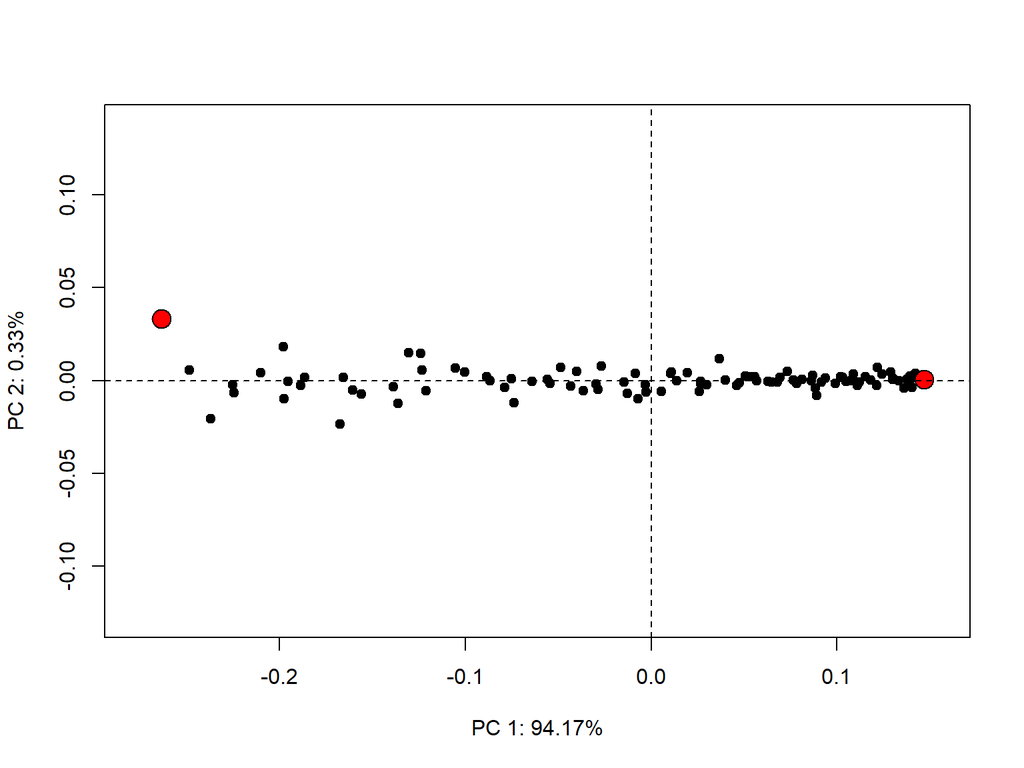

# Mean Substitution

- What’s going on here?
  - Mean substitution does not account for systematic variation (e.g., allometry)
  - If shape covaries with some factor (e.g., size!), estimates will be off
  - Will over- or under-estimate landmark locations relative to the specimen

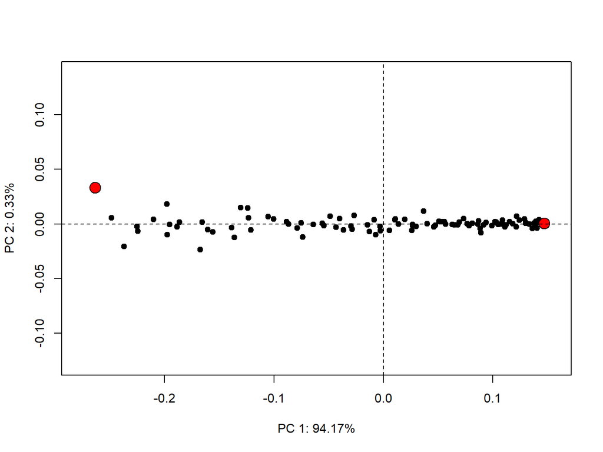

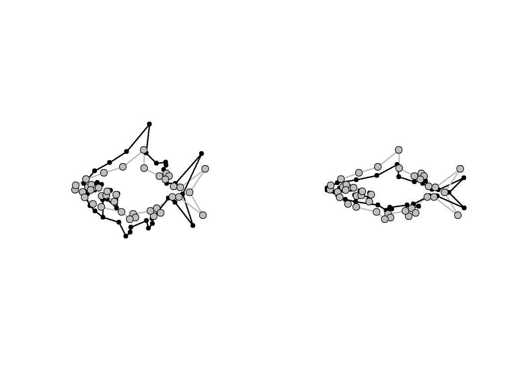

- **Mean substitution should not be used!**

# 3: TPS Interpolation

- Use thin-plate spline to estimate location of missing landmarks

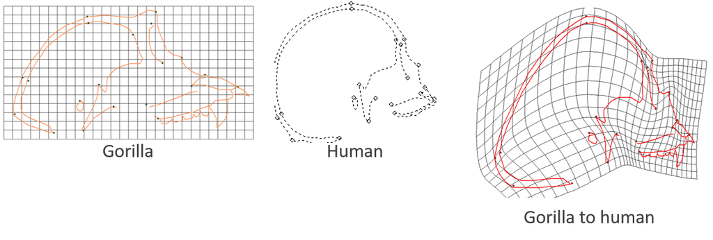

# 3: TPS Interpolation

- Use thin-plate spline to estimate location of missing landmarks

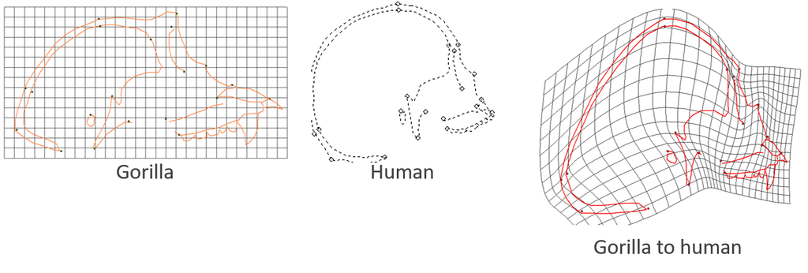

- Procedure
  - 1: Identify common landmarks in both reference and target
  - 2: Calculate TPS interpolation
  - 3: Locations of missing landmarks in target estimated from their location in reference, filtered through TPS

###### Bookstein et al. (1999). *New. Anat.*; Gunz et al. (2009). *J. Hum. Evol.*

# TPS Interpolation: Concept

- Procedure
  - 1: Identify common landmarks in both reference and target
  - 2: Calculate TPS interpolation
  - 3: Locations of missing landmarks in target estimated from their location in reference, filtered through TPS

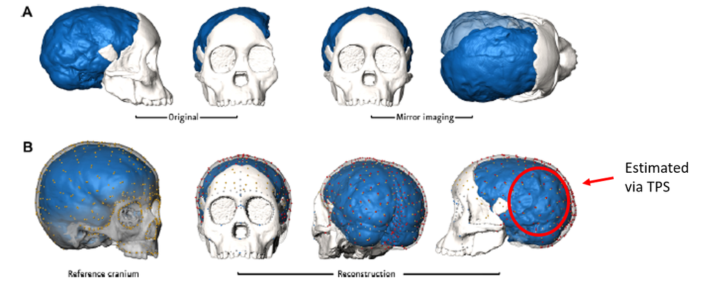

###### Bookstein et al. (1999). *New. Anat.*; Gunz et al. (2009). *J. Hum. Evol.*

# TPS Interpolation: Example 1

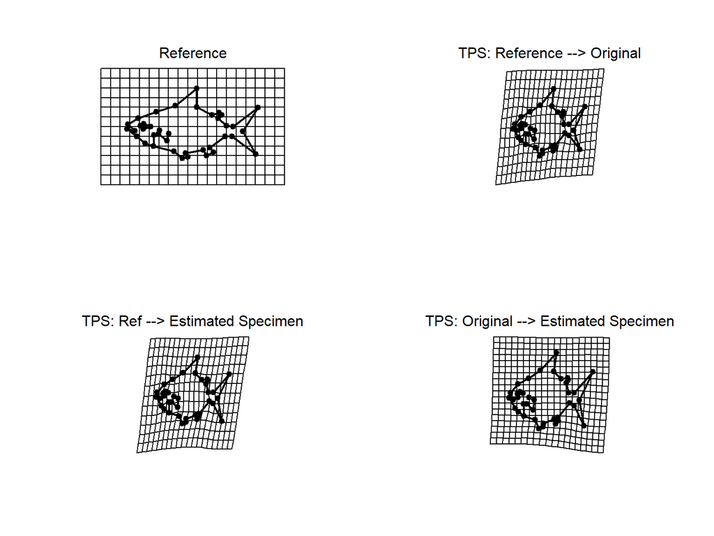

$\small{D}_{Proc_{Ref-Orig}} = 0.26$ $\small{D}_{Proc_{Ref-Est}} = 0.27$

# TPS Interpolation: Example 2

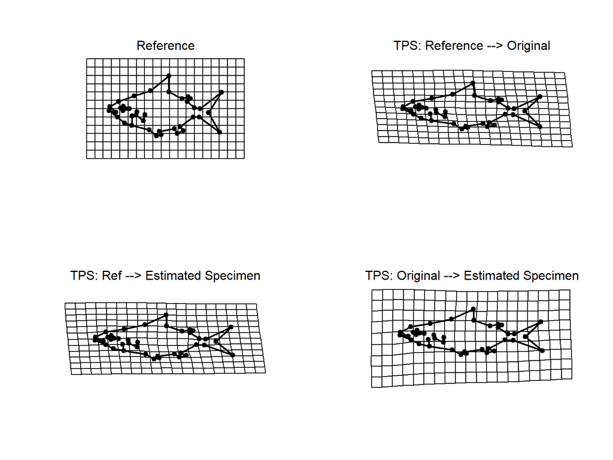

$\small{D}_{Proc_{Ref-Orig}} = 0.15$ $\small{D}_{Proc_{Ref-Est}} = 0.15$

$\small{D}_{Proc_{Orig-Est}} = 0.011$ **MUCH Better!**

# TPS Interpolation

**Advantages** - Exploits spatial relationships of anatomy within a specimen

**Disadvantages** - Less accurate if many landmarks in a region missing (common with fossils) - Does not leverage additional covariation information in sample

- TPS interpolation is *very* useful, but may be improved upon

# 4: Regression Interpolation

- Use covariation between landmarks to estimate locations
- Procedure
  - 1: Superimpose all complete specimens
  - 2:Regress landmarks with missing values against complete specimens
  - 3: Use post-hoc prediction on regression for missing landmarks
  - 4: Predicted values serve as missing landmark locations

###### Note: Regression scores of PLS typically used as $\small{p>n}$

###### See Gunz et al. (2009). *J. Hum. Evol.*; Arbour and Brown (2014). *Methods. Ecol. Evol.*

# Regression Interpolation: Example 1

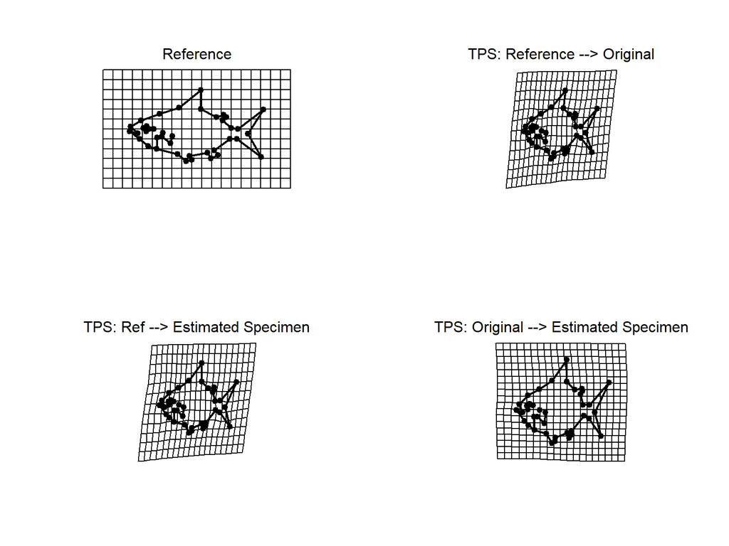

$\small{D}_{Proc_{Ref-Orig}} = 0.26$ $\small{D}_{Proc_{Ref-Est}} = 0.27$

$\small{D}_{Proc_{Orig-Est}} = 0.030$ **Pretty good!**

# Regression Interpolation: Example 2

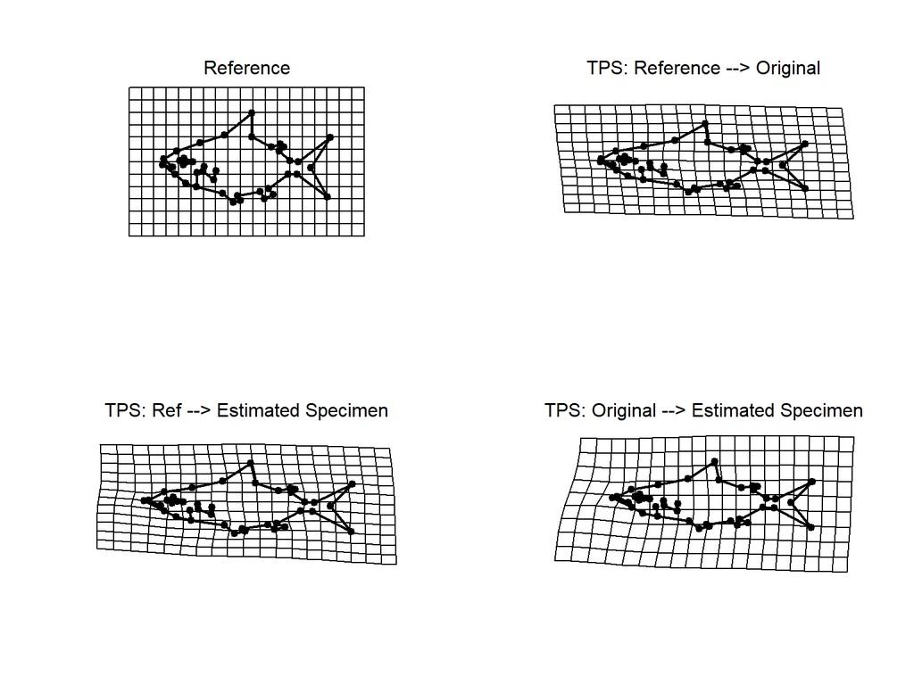

$\small{D}_{Proc_{Ref-Orig}} = 0.15$ $\small{D}_{Proc_{Ref-Est}} = 0.15$

# Regression Interpolation

**Advantages** - Exploits spatial relationships of anatomy within a specimen - Leverages covariation between anatomical landmarks - Leverages covariation within a sample

**Disadvantages** - May be less accurate when small samples are examined

###### NOTE: Estimation may be further improved by considering within-sample variation (e.g., use specimens within a species)

- Regression interpolation is *VERY* useful, but is it universally better?

# Methods Comparisons

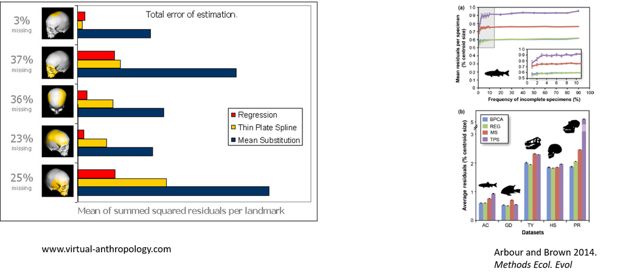

- HIgher error with $\small{\uparrow}$ missing landmarks and $\small{\uparrow}$ specimens containing missing data
- **Regression method generally preferred**

# Flow of Computations

- GMM Workflow should be augmented to account for missing landmarks
  - 1: Digitize data & read into geomorph
  - 2: **Estimate missing landmarks**
  - 3: GPA + projection
  - 4: Statistical analyses and visualization

# Missing Data: Conclusions

- Missing data has been a major challenge to GM analyses
- Deleting specimens or landmarks ignores information
- Morphometric-based estimation
  - Exploit symmetry in data
  - Use TPS interpolation
- ‘Classical’ statistical approaches extended to morphometrics
  - Regression incorporates covariation in sample
- **Regression approach appears most robust**